# Numpy

[figure not shown]

```python
from PIL import Image
Image.open("numpyimage.jpg")
```

NumPy is a core library for scientific computating in Python programming language, adding support for large, multi-dimensional arrays and matrices, along with a large collection of high-level mathematical functions to operate on these arrays.

It has powerful n-dimensional array objects and provides different tools for working with these arrays. It has a lot of built in functions which is useful in linear algebra and fourier transformation and random number capability.

It works efficiently with arrays and metrices in python.

# Contents

1. Installation of Numpy
2. Numpy array 1D 2D
3. Numpy array versus List
4. Basic operation on numpy array  
   a. size  
   b. shape  
   c. dimension  
   d. itemsize  
   e. dtype
5. Generating points using linspace and arange
6. Reshape and Resize
7. Basic maths on numpy array  
   a. Min  
   b. Max  
   c. Index of max and min  
   d. Mean  
   e. Sum  
   f. Addition  
   g. Subtraction  
   h. Multiplication  
   i. Division  
   j. Standard Deviation  
   k. Square Root  
   l. Data type conversion
8. Basic Linear Algebra  
   a. Array of Ones  
   b. Array of Zeros  
   c. Diagonal Matrix  
   d. Repeated Arrays  
   e. Dot product  
   f. Square of Array  
   g. Transpose of Array
9. Stacking Array and creating column vector
10. Indexing and Slicing 11.Numpy special function  
    a. sin  
    b. cos  
    c. tan  
    d. exponent  
    e. log

# 1. Installation of Numpy

For Linux  
pip install numpy

Throgh conda in Anaconda  
conda install -c anaconda numpy

# 2. Numpy array 1D 2D

```python
#importing the numpy library
import numpy as np

#one dimension array
arr1d = np.array([1,2,3,4,5,6])
print("one-dim numpy array ",arr1d)

#two dimensional array
arr2d = np.array([(1,2,3,4,5,6),(1,2,3,4,5,6)])
print("two-dim numpy array\n", arr2d)
```

```
one-dim numpy array  [1 2 3 4 5 6]
two-dim numpy array
 [[1 2 3 4 5 6]
 [1 2 3 4 5 6]]
```

# 3. Numpy array versus List

### Advantages of Numpy over list

**1. Less Memory**  
**2. Fast**  
**3. Convenient**

# 4. Basic operation on numpy array

```python
#import numpy array
import numpy as np

#2-d numpy array
arr = np.array([(1,2,3,4,5,6),(1,2,3,4,5,6)])

#display the array
print("Array ->",arr)

#size of the array
print("size -> ",arr.size)

#shape of the array
print("shape -> ",arr.shape)

#dimension of array
print("Dimension ->",arr.ndim)

#item size of the array
print("Item size ->",arr.itemsize)

#datatype of the array
print("Data type ->", arr.dtype)
```

```
Array -> [[1 2 3 4 5 6]
 [1 2 3 4 5 6]]
size ->  12
shape ->  (2, 6)
Dimension -> 2
Item size -> 4
Data type -> int32
```

# 5. Generating points using linspace and arange

**np.arange(start,stop,step,dtype=None)**  
It returns an array of evenly spaced values. stop is excluded.

**np.linspace(start, stop, num=50, endpoint=True, retstep=False, dtype=None)**  
The linspace function is similar to arnage function of numpy except that we will tell it how many numbers we want to return and it will split up the equally space between the given interval.

There are num equally spaced samples in the closed interval [start, stop] or the half-open interval [start, stop) (depending on whether endpoint is True or False)

```python
# import numpy library
import numpy as np

#generating points using arange
arr1 = np.arange(0,10,2,dtype='f')
print('data generated using arange ->',arr1)

#generating points using linspace
arr2 = np.linspace(0,10,5,endpoint=False,dtype='i')
print('data generated using linspace ->',arr2)
```

```
data generated using arange -> [0. 2. 4. 6. 8.]
data generated using linspace -> [0 2 4 6 8]
```

# 6. Reshape and Resize

```python
import numpy as np

#gemerate some points
arr = np.linspace(0,6,6,dtype='i')
print("Generated array ->",arr)
print("Size of array ->",arr.size)
print("Shape of array ->",arr.shape)

#reshape the array Note: the reshape value should be such that total number of element remain same as the original array
reshaped_arr = arr.reshape(2,3)
print("Reshaped array ->",reshaped_arr)
#Note: After reshape, the array didn't change, but only outputs a temporary array reshape.
print(arr)


#resize the array
resized_arr = arr.resize(2,3)
print("Resized array ->",resized_arr)
#Note : After resize the the original array changed it's shape and it does not output a temporary array shape it just
#overwrite the original array.
print(arr)
```

```
Generated array -> [0 1 2 3 4 6]
Size of array -> 6
Shape of array -> (6,)
Reshaped array -> [[0 1 2]
 [3 4 6]]
[0 1 2 3 4 6]
Resized array -> None
[[0 1 2]
 [3 4 6]]
```

# 7. Basic maths on numpy array

```python
#import numpy library
import numpy as np

#generate a random array using rand
#np.random.randint(low, high=None, size=None, dtype='l')
random_arr = np.random.randint(1,high=100,size=6,dtype='l')
print(random_arr)

#min of the array
print("Min of array ->",random_arr.min())

#max of the array
print("Max of array ->",random_arr.max())

#index where min occured in the array
print("Index of min number->",random_arr.argmin())

#index where max occured in the array
print("Index of max number ->",random_arr.argmin())

#mean of the array
print("Mean of array ->",random_arr.mean())

#sum of elements of the array
print("Sum of elements of array ->",random_arr.sum())


#square of the array
print("Square of the array ->",random_arr**2)
#print("Square of the array ->",np.square(random_arr))

#square root of the array
print("Square root of the array ->",np.sqrt(random_arr))

#standard-deviation of the array
print("Standard deviation of the array ->",np.std(random_arr))

#data type conversion - i,f,d,c
print("Change data type to float ->",random_arr.astype('i'))
```

[output not shown]

```python
#define an another array
random_arr2 = np.random.randint(0,50,6,dtype='l')
print("Another random array ->",random_arr2)

#adding two arrays random_arr and random_arr2
sum = random_arr + random_arr2
print("Sum of arrays ->",sum)

#subtracting two arrays
sub = random_arr - random_arr2
print("Difference of arrays ->",sub)

#multiplication of two arrays
mul = random_arr*random_arr2
print("Multiplication of arrays ->",mul)

#Division of two arrays
div = random_arr / random_arr2
```

```
Another random array -> [19 43 22 28 46  1]
Sum of arrays -> [ 78  90  98 122 145  67]
Difference of arrays -> [40  4 54 66 53 65]
Multiplication of arrays -> [1121 2021 1672 2632 4554   66]
```

# 8. Basic Linear Algebra

```python
#gnerating arrays of one's
arr_ones = np.ones((3,3),dtype='i')
print("Array of ones \n",arr_ones)

#generating arrays of zeros
arr_zeros = np.zeros((3,3))
print("Array of zeros \n",arr_zeros)

#generating diagonal matrix
#Case 1 : all diagonal element 1 - pass dimension of the array
arr_identity = np.eye(3)
print("Identity matrix \n",arr_identity)

#case 2: diagonal elements different - pass a list of diagonal elements
diagonal = [2,3,1]
arr_diagonal = np.diag(diagonal)
print("Diagonal matrix\n",arr_diagonal)
```

```
Array of ones
 [[1 1 1]
 [1 1 1]
 [1 1 1]]
Array of zeros
 [[0. 0. 0.]
 [0. 0. 0.]
 [0. 0. 0.]]
Identity matrix
 [[1. 0. 0.]
 [0. 1. 0.]
 [0. 0. 1.]]
Diagonal matrix
 [[2 0 0]
 [0 3 0]
 [0 0 1]]
```

```python
#repeated array
org_arr = np.array([1,2,3])

#to repeat the entire array n times - pass a list - if numpy array is passed then it just do the multiplication
repeated_arr = np.array([1,2,3]*3)
print("Repeated array ->",repeated_arr)

#to repeat the each elements n times
repeat_element = np.repeat(org_arr,3)
print("Repeated elements of array ->",repeat_element)

#dot product of two arrays
dot_product = org_arr.dot(np.array([2,3,4]))
print("Dot product of two array ",dot_product)


#square of array
squared_arr = np.square(org_arr)
#squared_arr = org_arr**2
print("Squared of array->",squared_arr)

#Transpose of matrix - columns-->rows and rows--->columns
matrix = np.array([(1,2,3),(4,5,6)])
print("Matrix is \n",matrix)
transposed_matrix = matrix.T
print("Transposed matrix \n",transposed_matrix)
```

```
Repeated array -> [1 2 3 1 2 3 1 2 3]
Repeated elements of array -> [1 1 1 2 2 2 3 3 3]
Dot product of two array  20
Squared of array-> [1 4 9]
Matrix is
 [[1 2 3]
 [4 5 6]]
Transposed matrix
 [[1 4]
 [2 5]
 [3 6]]
```

# 9. Stacking Array and creating column vector

Stacking of a array can be done in two forms  
a. **vertical stacking**  
Stack arrays in sequence vertically (row wise).  
This is equivalent to concatenation along the first axis after 1-D arrays of shape (N,) have been reshaped to (1,N). Rebuilds arrays divided by vsplit.  
b. **horizontal stacking**  
Stack arrays in sequence horizontally (column wise).  
This is equivalent to concatenation along the second axis, except for 1-D arrays where it concatenates along the first axis. Rebuilds arrays divided by hsplit.

```python
#vertical stacking
arr = np.array([1,2,3])
vertical_stacked = np.vstack([arr,5*arr])
print("same array vertically stacked\n",vertical_stacked)

a = np.array([1,2,3])
b = np.array([4,5,6])

print("Vertical stack of given two arrays ",np.vstack((a,b)))

#horizontal stack of two array
print("Horizontal stack of given two arrays ",np.hstack((a,b)))
```

```
same array vertically stacked
 [[ 1  2  3]
 [ 5 10 15]]
Vertical stack of given two arrays  [[1 2 3]
 [4 5 6]]
Horizontal stack of given two arrays  [1 2 3 4 5 6]
```

```python
#column vectors
arr = np.array([(1,2,3),(4,5,6)])
print("The array is \n",arr)
column_vector = np.ravel(arr)
print("The column vector of the given array\n",column_vector)
```

```
The array is
 [[1 2 3]
 [4 5 6]]
The column vector of the given array
 [1 2 3 4 5 6]
```

# 10. Indexing, Slicing, Axis

### Indexing and Slicing

```python
#generate a array
arr = np.random.randint(0,20,10,dtype='i')
print("The array is ->",arr)

#get a element at given index
print("Given index element->",arr[2])

#get elements in given interval from the array
print("A set of elements from the array ->",arr[2:4])

#resape the the arr
new_arr = arr.reshape((2,5))
print("New Reshaped array \n",new_arr)

#get a particular element by its index
print("Get a element at given index ->",new_arr[1][1])

#get the entire row at a given column
print("Entire colum \n",new_arr[:,1:3])
```

```
The array is -> [18 19  5 11  2 13 15 18 18 12]
Given index element-> 5
A set of elements from the array -> [ 5 11]
New Reshaped array
 [[18 19  5 11  2]
 [13 15 18 18 12]]
Get a element at given index -> 15
Entire colum
 [[19  5]
 [15 18]]
```

### Axis

Column corresponds to axis = 0  
Row corresponds to axis = 1

```python
#create 2-d array
arr = np.array([(1,2,3),(4,5,6)])
print("The array is \n",arr)

#sum of array along the axis = 0 i.e. along column
print("Sum along axis =0 \n",arr.sum(axis=0))

#sum of array along the axis = 1 i.e. along row
print("Sum along axis =0 \n",arr.sum(axis=1))
```

```
The array is
 [[1 2 3]
 [4 5 6]]
Sum along axis =0
 [5 7 9]
Sum along axis =0
 [ 6 15]
```

# 11. Numpy special function

### sin

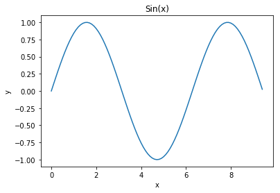

```python
#import the libraries
import numpy as np
import matplotlib.pyplot as plt

x = np.arange(0,3*np.pi,0.1)

y_sin = np.sin(x)

#adding labels and title
plt.xlabel("x")
plt.ylabel("y")
plt.title("Sin(x)")

plt.plot(x,y_sin)
plt.show()
```

### cos

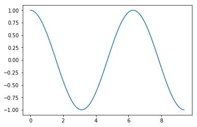

```python
#cos function
y_cos = np.cos(x)

plt.plot(x,y_cos)
plt.show()
```

### tan

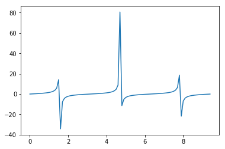

```python
#tan function
y_tan = np.tan(x)

plt.plot(x,y_tan)
plt.show()
```

### exponent e^x

```python
#create an array
arr = np.array([1,2.71828183,10])
print(np.exp(arr))
```

```
[2.71828183e+00 1.51542623e+01 2.20264658e+04]
```

### log

log(x) is natural log i.e. log to the base e  
log10(x) is log to the base 10

```python
#print natural log of the above array
print("Natural log ->",np.log(arr))

#print log base 10 of the above array
print("Log base 10 ->",np.log10(arr))
```

```
Natural log -> [0.         1.         2.30258509]
Log base 10 -> [0.         0.43429448 1.        ]
```

## Thank You

**Sanjeet kumar**  
School of AI, Hubli  
sanjeetiiitd@gmail.com